# Accounting for Non-independence

## Independence

- Observations are independent if the value or occurrence of one *does not* influence any others
- Standard assumption of most statistical tests (Independent and Identically Distributed)
- In biological situations, independence assumption is often violated

[figure not shown]

## When is the independence assumption violated?

1. Repeat sampling over time of the same location, individual, or other experimental unit (e.g., time series)
2. When there is a hierarchical structure to the data
   - e.g., several samples at each site (block design)
3. Spatial relationships
4. Shared ancestry
   - Phylogenetic relatedness (between populations/species)
   - Genetic relatedness (between individuals within populations/species)
5. Other

## Why is non-independence a problem?

Hemoglobin levels in six species of rodents

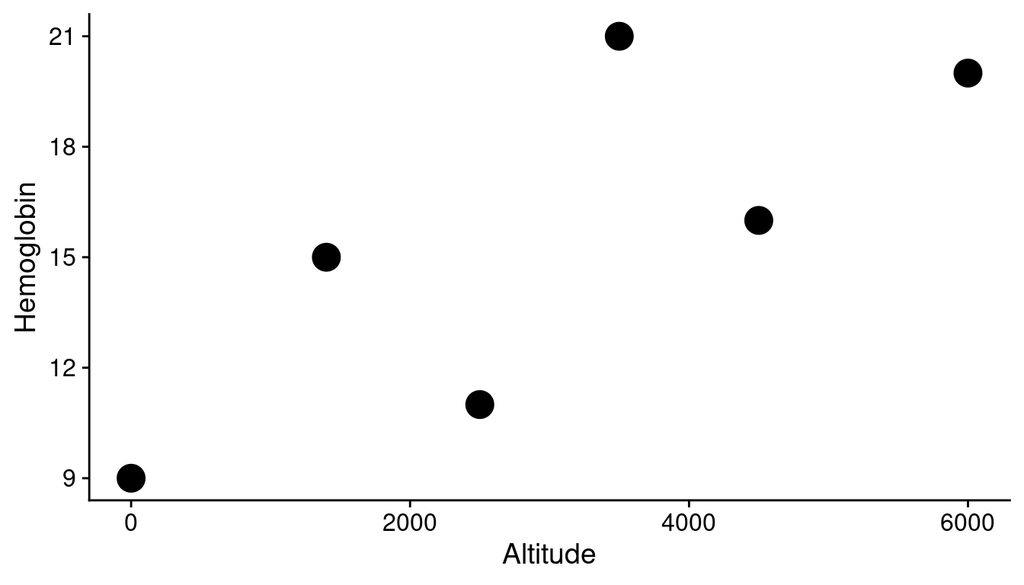

## Why is non-independence a problem?

Hemoglobin levels in six species of rodents

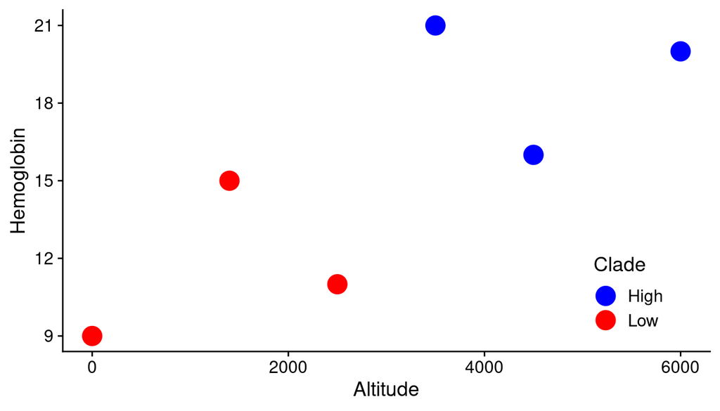

## Why is non-independence a problem?

**Pseudoreplication**: artificially inflated sample size lead to unfounded confidence

[figure not shown]

## Conventional statistics assume

[figure not shown]

## Genotype-Phenotype Relationships

Is a given genotype associated with a phenotype of interest?

- Consider two populations with ancestry differences
- Not accounting for ancestry differences can lead to spurious associations
- Population structure & relatedness are issues for all genetic association studies

## Genotype-Phenotype Relationships

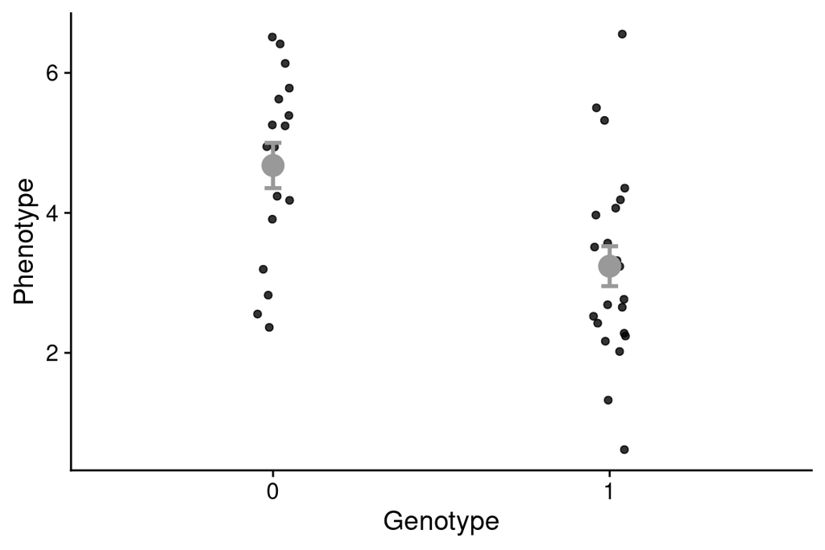

Is a given genotype associated with a phenotype of interest?

## Genotype-Phenotype Relationships

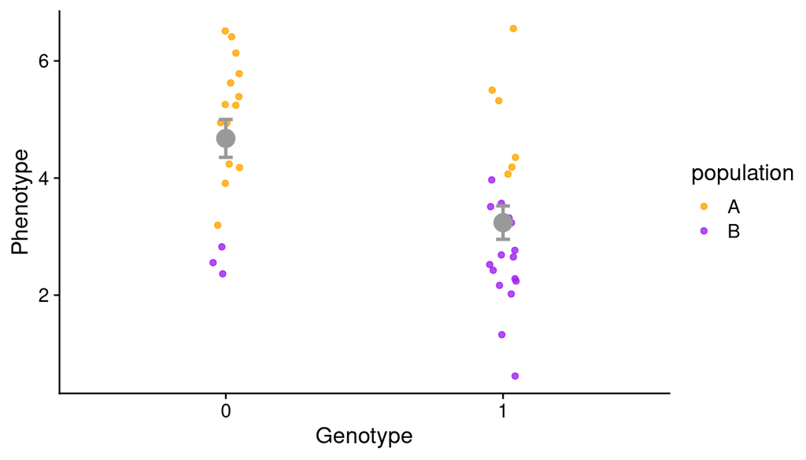

An effect of both 1) different allele frequency in two pops, and 2) different average trait value in two pops

## Repeated sampling

Review 09-3 and 09-4

- Squid growth
- Orthodontic growth
- Yearly climate data

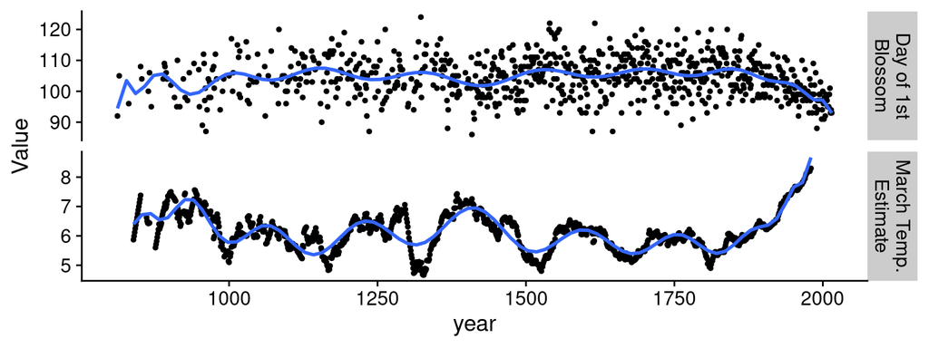

## Hierarchical structure

Review 09-3 and 09-4

- Nested levels of observations
- Turning hummingbirds
- Intertidal species richness

## Similarities between spatial, phylogenetic, and pedigree analyses

- Pairwise “distance” between observations represented by a matrix
- Sometimes
  - Variance-covariance matrix
  - Normalized to maximum distance
- Weights the regression by how closely “related” the observed values are
  - Accounts for expectation that spatial or genetic close relatives will be more similar than expected by chance

## Spatial relationships

Irregular sampling along the Missouri River

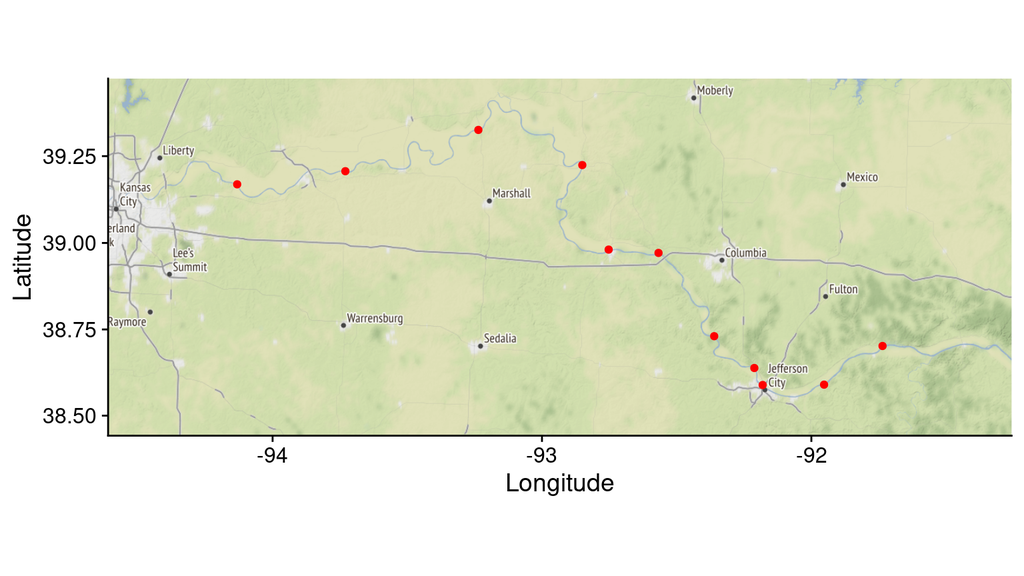

## Spatial relationships

```
##       [,1] [,2] [,3] [,4] [,5] [,6] [,7] [,8] [,9] [,10] [,11]
##  [1,]    0   35   79  111  121  177  214  200  161   137   181
##  [2,]   35    0   45   76   88  146  182  169  130   104   151
##  [3,]   79   45    0   35   57  117  147  138  101    70   123
##  [4,]  111   76   35    0   28   85  113  105   69    37    91
##  [5,]  121   88   57   28    0   60   94   82   44    16    66
##  [6,]  177  146  117   85   60    0   42   23   17    48     6
##  [7,]  214  182  147  113   94   42    0   23   54    78    41
##  [8,]  200  169  138  105   82   23   23    0   39    68    20
##  [9,]  161  130  101   69   44   17   54   39    0    32    22
## [10,]  137  104   70   37   16   48   78   68   32     0    54
## [11,]  181  151  123   91   66    6   41   20   22    54     0
```

## Shared Ancestry

- As soon as you have comparative data, you must consider the relationships among your taxa
  - No longer an option (30+ years of methods)
- Not concerned with making the tree(s)

*Trees are hypotheses of relationships. You have hypotheses resting on hypotheses.*

## Is body size associated with home range area in mammals?

Data from Garland et al. (1992)

- Body mass (km)
- Home range area (km<sup>2</sup>)
- “49lbr” data

## Home range vs. body mass

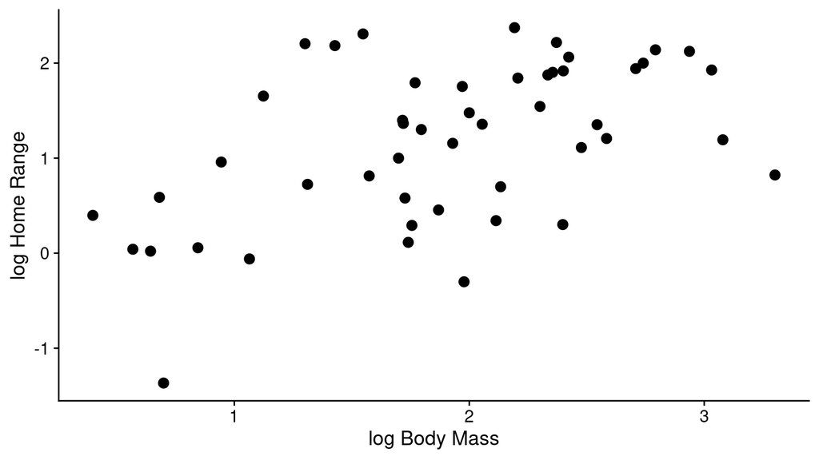

## Home range vs. body mass

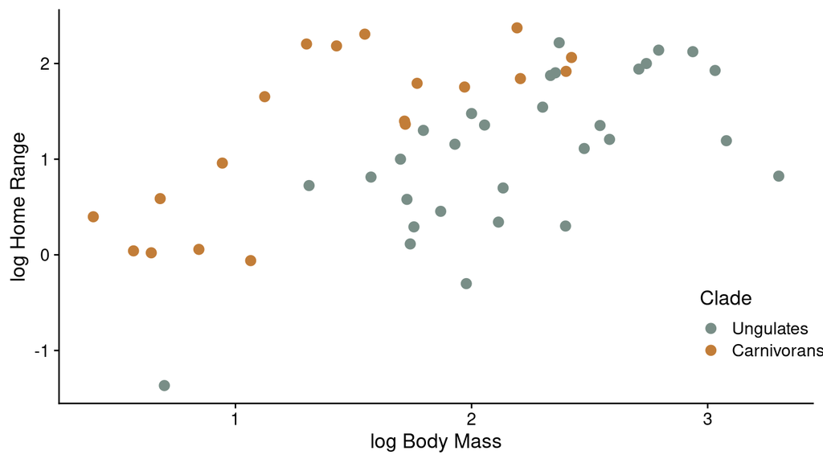

## Home range vs. body mass

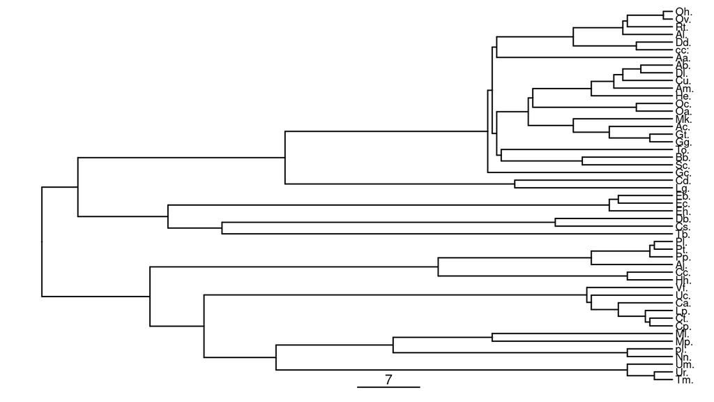

## Home range vs. body mass

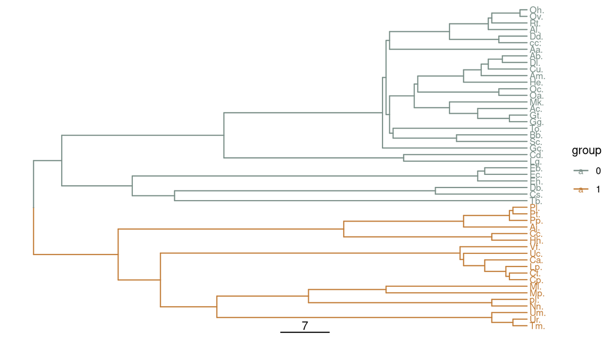

## Why phylogenetic comparative methods?

1. Meet the assumptions of standard statistical tests
   - Any test you can do using “standard” methods has a phylogenetically informed counterpart.
   - What is your evolutionary model?
2. Ask and answer interesting evolutionary questions
   - Trait evolution (continuous or categorical)
   - Trait co-evolution
   - Rates of evolution (identify nodes when rates shift significantly)
   - What is your evolutionary model?

## Home range vs. body mass

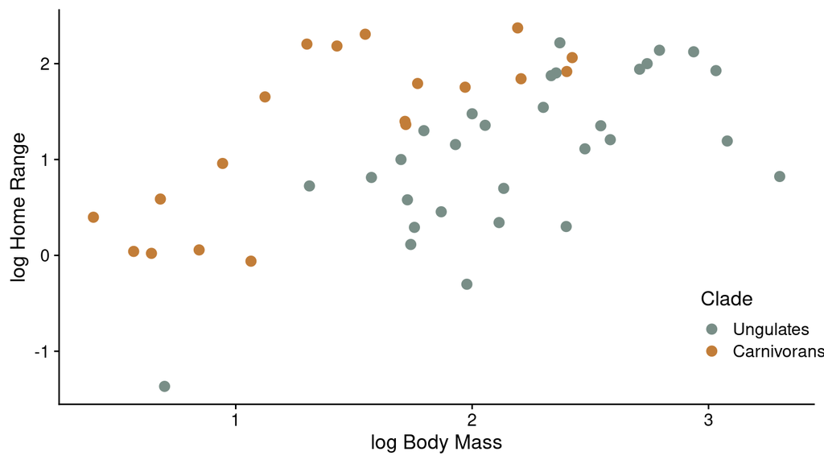

## Working with `nlme::gls()`

- We used `gls()` to fit the squid model, allowing correlated variance on a per-month basis
- Phylogenetically based correlation variation is a similar issue
- Choose a phylogenetic correlation structure

## Phylogenetic correlation structures

See ?`corClasses`

- `corBrownian`: Brownian motion model of evoltion
- `corPagel`: Pagel’s \(\lambda\) branch length transformation
- `corMartins`: Stabilizing selection evolutinary model originally proposed by Martins and Hansen (1997)
- `corBlomberg`: Accelerating-Decelerating evolutionary model of Blomberg et al. (2003)

## Model 1: Mass, BM

```r
library(nlme)
fm1 <- gls(log_Home_Range ~ log_Mass, data = lbr,
           correlation = corBrownian(phy = tree))
summary(fm1)
```

## Model 1: Mass, BM

[output not shown]

## Model 2: Mass + Clade, BM

```r
fm2 <- gls(log_Home_Range ~ log_Mass + Clade , data = lbr,
           correlation = corBrownian(phy = tree, form = ~ Species))
summary(fm2)
```

```
## Generalized least squares fit by REML
##   Model: log_Home_Range ~ log_Mass + Clade
##   Data: lbr
##        AIC      BIC    logLik
##   92.13749 99.45206 -42.06875
##
## Correlation Structure: corBrownian
##  Formula: ~Species
##  Parameter estimate(s):
## numeric(0)
##
## Coefficients:
##                      Value Std.Error   t-value p-value
## (Intercept)      -2.233013 0.8012034 -2.787073  0.0077
## log_Mass          1.317072 0.1777494  7.409710  0.0000
## CladeCarnivorans  1.605512 1.0302879  1.558314  0.1260
##
##  Correlation:
##                  (Intr) lg_Mss
## log_Mass         -0.557
## CladeCarnivorans -0.648  0.200
##
## Standardized residuals:
##        Min         Q1        Med         Q3        Max
## -1.0443623 -0.1687814  0.1826581  0.6855996  1.0732801
##
## Residual standard error: 1.236984
## Degrees of freedom: 49 total; 46 residual
```

## Model 3: Mass * Clade, BM

```r
fm3 <- gls(log_Home_Range ~ log_Mass * Clade , data = lbr,
           correlation = corBrownian(phy = tree, form = ~ Species))
summary(fm3)
```

```
## Generalized least squares fit by REML
##   Model: log_Home_Range ~ log_Mass * Clade
##   Data: lbr
##        AIC      BIC    logLik
##   94.16136 103.1947 -42.08068
##
## Correlation Structure: corBrownian
##  Formula: ~Species
##  Parameter estimate(s):
## numeric(0)
##
## Coefficients:
##                               Value Std.Error   t-value p-value
## (Intercept)               -2.322649 0.8699739 -2.669792  0.0105
## log_Mass                   1.352785 0.2200051  6.148882  0.0000
## CladeCarnivorans           1.791226 1.2329695  1.452774  0.1532
## log_Mass:CladeCarnivorans -0.106957 0.3807330 -0.280924  0.7801
##
##  Correlation:
##                           (Intr) lg_Mss CldCrn
## log_Mass                  -0.635
## CladeCarnivorans          -0.706  0.448
## log_Mass:CladeCarnivorans  0.367 -0.578 -0.536
##
## Standardized residuals:
##        Min         Q1        Med         Q3        Max
## -1.0564654 -0.1557668  0.1917349  0.6952910  1.0664477
##
## Residual standard error: 1.249557
## Degrees of freedom: 49 total; 45 residual
```

## Model comparison with AICc

|  | Mass | Mass + Clade | Mass * Clade |
| --- | --- | --- | --- |
| Brownian Motion | 95 | 93 | 95.6 |

Additive model is preferred (but all are pretty similar)

```r
coef(fm2)
```

```
##      (Intercept)         log_Mass CladeCarnivorans
##        -2.233012         1.317072         1.605512
```

## Kinship (non-independence) as a tool

When modeled correctly, non-independence between samples can be very useful:

- Forms the basis for how we estimate heritabilities, genetic correlations, etc.
- Very similar in concept to repeatability
- Estimate the variance within families/lines (groups) versus between families/lines
- Modern methods can consider complex pedigrees or relatedness estimated directly from genomic data

## Heritability and genetic correlation

[figure not shown]

## Load pedigree

```r
library(MCMCglmm)
library(kinship2)

data(BTped)
str(BTped)
```

```
## 'data.frame':    1040 obs. of  3 variables:
##  $ animal: Factor w/ 1040 levels "Fem2","Fem20",..: 669 671 680 630 640 1007 3 158 629 635 ...
##  $ dam   : Factor w/ 106 levels "Fem2","Fem20",..: NA NA NA NA NA NA NA NA NA NA ...
##  $ sire  : Factor w/ 106 levels "Male10","Male100",..: NA NA NA NA NA NA NA NA NA NA ...
```

## Look at part of pedigree

```
##       animal     dam    sire
## 66   R187920    <NA>    <NA>
## 172  R187921    <NA>    <NA>
## 325  R187726 R187920 R187921
## 411  R187724 R187920 R187921
## 503  R187723 R187920 R187921
## 838  R187613 R187920 R187921
## 932  R187612 R187920 R187921
## 1030 R187609 R187920 R187921
```

## Plot part of pedigree

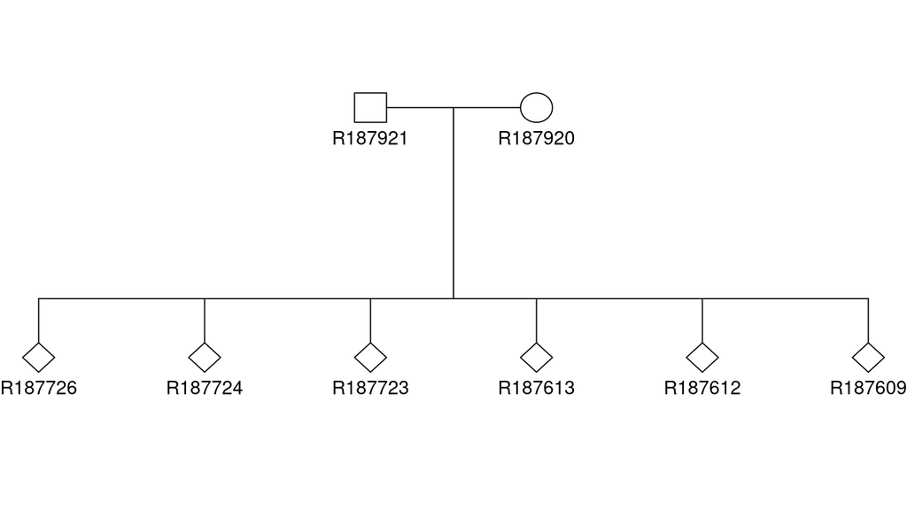

## Genetic distance

```
##         R187920 R187921 R187726 R187724 R187723 R187613
## R187920     1.0     0.0     0.5     0.5     0.5     0.5
## R187921     0.0     1.0     0.5     0.5     0.5     0.5
## R187726     0.5     0.5     1.0     0.5     0.5     0.5
## R187724     0.5     0.5     0.5     1.0     0.5     0.5
## R187723     0.5     0.5     0.5     0.5     1.0     0.5
## R187613     0.5     0.5     0.5     0.5     0.5     1.0
```

## Data

```r
data(BTdata)
head(BTdata)
```

```
##        tarsus       back  animal     dam fosternest  hatchdate  sex
## 1 -1.89229718  1.1464212 R187142 R187557      F2102 -0.6874021  Fem
## 2  1.13610981 -0.7596521 R187154 R187559      F1902 -0.6874021 Male
## 3  0.98468946  0.1449373 R187341 R187568       A602 -0.4279814 Male
## 4  0.37900806  0.2555847 R046169 R187518      A1302 -1.4656641 Male
## 5 -0.07525299 -0.3006992 R046161 R187528      A2602 -1.4656641  Fem
## 6 -1.13519543  1.5577219 R187409 R187945      C2302  0.3502805  Fem
```

## Heritability of tarsus length

```r
prior <- list(R = list(V = 0.002, n = 2),
              G = list(G1 = list(V = 0.002, n = 2)))

fm1 <- MCMCglmm(
  fixed = tarsus ~ 1,
  random = ~ animal,
  prior = prior,
  family = c("gaussian"),
  nitt = 60000, burnin = 10000, thin = 25,
  data = BTdata, pedigree = BTped,
  verbose = FALSE)
save(fm1, file = "../data/BT_herit.Rda")
```

## Fixed effects

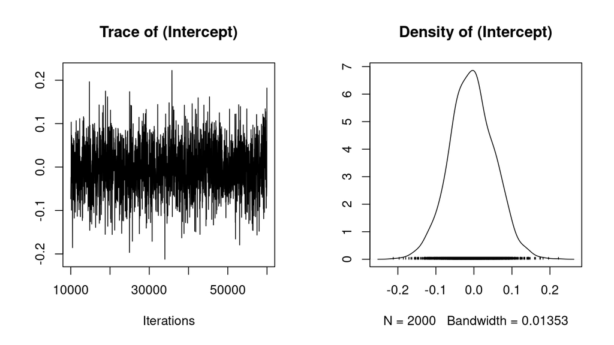

```r
plot(fm1$Sol)
```

## Random effects

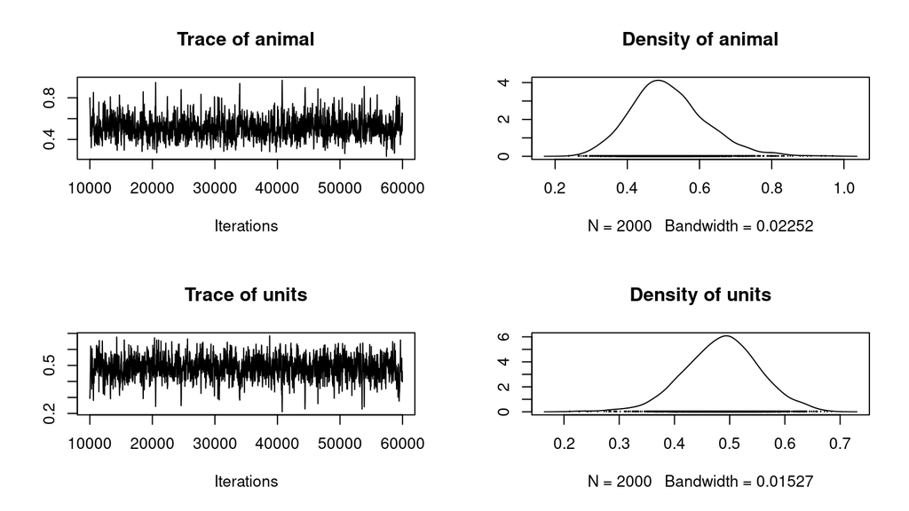

```r
plot(fm1$VCV)
```

## Heritability

\[h^2 = \frac{V_a}{V_a + V_r}\]

```r
h2 <- fm1$VCV[, "animal"] /
  (fm1$VCV[, "animal"] + fm1$VCV[, "units"])
```

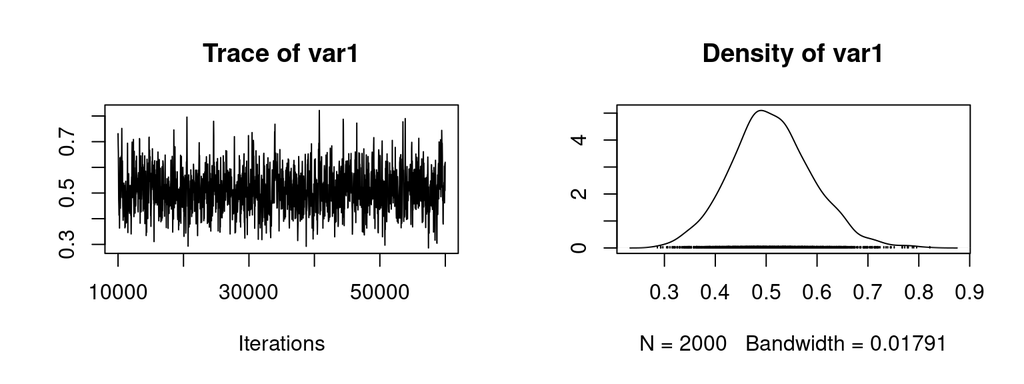

## Heritability

```r
median(h2)
```

```
## [1] 0.5071815
```

```r
HPDinterval(h2)
```

```
##          lower     upper
## var1 0.3451464 0.6579368
## attr(,"Probability")
## [1] 0.95
```

## Genetic correlation

```r
prior <- list(R = list(V = diag(2) * 1.001, n = 2),
              G = list(G1 = list(V = diag(2)  * 1.001, n = 2)))

fm2 <- MCMCglmm(
  fixed = cbind(back, tarsus) ~ trait,
  random = ~ us(trait):animal,
  rcov = ~ us(trait):units,
  prior = prior,
  family = c("gaussian", "gaussian"),
  nitt = 60000, burnin = 10000, thin = 25,
  data = BTdata, pedigree = BTped,
  verbose = FALSE)
save(fm2, file = "../data/BT_genetic_correlation.Rda")
```

## Genetic correlation

```r
Genet_Corr <- fm2$VCV[ , "traittarsus:traitback.animal"] /
  sqrt(fm2$VCV[ , "traittarsus:traittarsus.animal"] *
         fm2$VCV[ , "traitback:traitback.animal"])
```

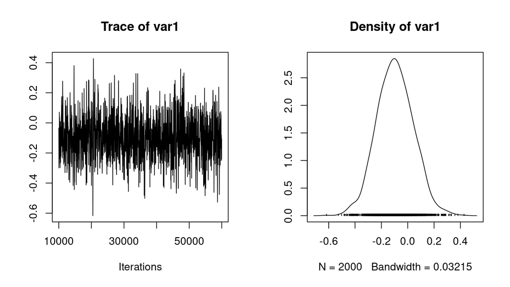

## Genetic correlation

```r
median(Genet_Corr)
```

```
## [1] -0.09755932
```

```r
HPDinterval(Genet_Corr)
```

```
##           lower     upper
## var1 -0.3499248 0.1825534
## attr(,"Probability")
## [1] 0.95
```

## References

Blomberg, S. P., T. Garland Jr, and A. R. Ives. 2003. Testing for Phylogenetic Signal in Comparative Data: Behavioral Traits Are More Labile. *Evolution* 57:717–745.

Garland, T., Jr, P. H. Harvey, and A. R. Ives. 1992. Procedures for the Analysis of Comparative Data Using Phylogenetically Independent Contrasts. *Syst. Biol.* 41:18–32.

Martins, E., and T. F. Hansen. 1997. Phylogenies and the Comparative Method: A General Approach to Incorporating Phylogenetic Information into the Analysis of Interspecific Data. *Am. Nat.* 149:646–667.